# Segmentation & Clustering

# Segmentation.

It means manually segmenting our data into different parts, e.g. by age/income etc.

# Clustering.

Machine learning technique to cluster data based on similarities.

## Hierarchical Clustering (manual):

defined by measuring the distance or correlation.

Distance measured Euclidian distance (like with a ruler), but because the points are defined on a plain, it is usually measured using Pythagoras theorem c = a^2 * b^2.

If Euclidian distance is unsuitable, e.g. on maps in cities, “manhattan” distance can be used.

```r
library(tidyverse)
library(cluster)
library(factoextra)
library(dendextend)
```

```r
head(USArrests)
```

|  | Murder | Assault | UrbanPop | Rape |
| --- | --- | --- | --- | --- |
| Alabama | 13.2 | 236 | 58 | 21.2 |
| Alaska | 10.0 | 263 | 48 | 44.5 |
| Arizona | 8.1 | 294 | 80 | 31.0 |
| Arkansas | 8.8 | 190 | 50 | 19.5 |
| California | 9.0 | 276 | 91 | 40.6 |
| Colorado | 7.9 | 204 | 78 | 38.7 |

check for NAs.

```r
summary(USArrests)
```

```
     Murder          Assault         UrbanPop          Rape
 Min.   : 0.800   Min.   : 45.0   Min.   :32.00   Min.   : 7.30
 1st Qu.: 4.075   1st Qu.:109.0   1st Qu.:54.50   1st Qu.:15.07
 Median : 7.250   Median :159.0   Median :66.00   Median :20.10
 Mean   : 7.788   Mean   :170.8   Mean   :65.54   Mean   :21.23
 3rd Qu.:11.250   3rd Qu.:249.0   3rd Qu.:77.75   3rd Qu.:26.18
 Max.   :17.400   Max.   :337.0   Max.   :91.00   Max.   :46.00
```

!Need to scale the data! because the algorithm is based on distances.

mean = 0, sd = 1

```r
library(tidyverse)
library(janitor)
```

```r
arrests <- USArrests %>%
  clean_names() %>%
  rownames_to_column("state") %>%
  mutate_if(is.numeric, scale)
```

```r
head(arrests)
```

|  | state | murder | assault | urban_pop | rape |
| --- | --- | --- | --- | --- | --- |
| 1 | Alabama | 1.24256408 | 0.7828393 | -0.5209066 | -0.003416473 |
| 2 | Alaska | 0.50786248 | 1.1068225 | -1.2117642 | 2.484202941 |
| 3 | Arizona | 0.07163341 | 1.4788032 | 0.9989801 | 1.042878388 |
| 4 | Arkansas | 0.23234938 | 0.2308680 | -1.0735927 | -0.184916602 |
| 5 | California | 0.27826823 | 1.2628144 | 1.7589234 | 2.067820292 |
| 6 | Colorado | 0.02571456 | 0.3988593 | 0.8608085 | 1.864967207 |

```r
summary(arrests)
```

```
    state                murder.V1            assault.V1          urban_pop.V1
 Length:50          Min.   :-1.6044046   Min.   :-1.5090416   Min.   :-2.3171363
 Class :character   1st Qu.:-0.8524835   1st Qu.:-0.7410815   1st Qu.:-0.7627068
 Mode  :character   Median :-0.1235217   Median :-0.1411127   Median : 0.0317794
                    Mean   : 0.0000000   Mean   : 0.0000000   Mean   : 0.0000000
                    3rd Qu.: 0.7948553   3rd Qu.: 0.9388312   3rd Qu.: 0.8435371
                    Max.   : 2.2068599   Max.   : 1.9947764   Max.   : 1.7589234
       rape.V1
 Min.   :-1.4874469
 1st Qu.:-0.6573508
 Median :-0.1208577
 Mean   : 0.0000000
 3rd Qu.: 0.5277383
 Max.   : 2.6443501
```

Calculate Eucl distance for “murder” between the states.

```r
diss_matrix <- arrests %>%
  column_to_rownames("state") %>%
  select(murder) %>%
  dist(method = "euclidean")
```

visualize the distance.

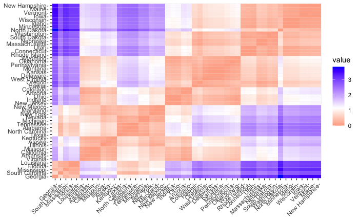

```r
fviz_dist(diss_matrix)
```

Complete method is the most widely used, but there are other distance calculation methods.

```r
clusters <- diss_matrix %>%
  hclust(method = "complete")
```

visualise

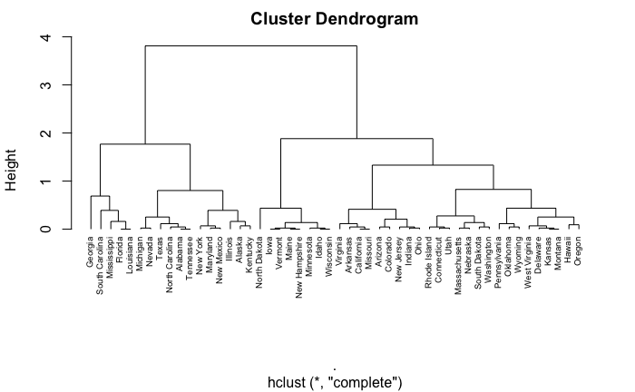

```r
#this is using base r, but GG dendrogram can be used to make it look nicer.
clusters %>%
  plot(cex = 0.6, hang = -2)
```

### Picking a number of clusters.

Depending on business context, the number of clusters may be different from the optimal number of clusters.

For the above model, the optimal number of clusters is 3!

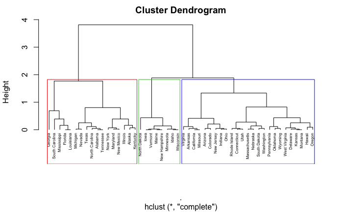

```r
plot(clusters, cex = 0.5, hang = -5)
rect.hclust(clusters, k = 3, border = 2:4)
```

```r
arrests_cluster_h3 <- arrests %>%
  mutate(murder_cluster = cutree(clusters, 3))
head(arrests_cluster_h3)
```

|  | state | murder | assault | urban_pop | rape | murder_cluster |
| --- | --- | --- | --- | --- | --- | --- |
| 1 | Alabama | 1.24256408 | 0.7828393 | -0.5209066 | -0.003416473 | 1 |
| 2 | Alaska | 0.50786248 | 1.1068225 | -1.2117642 | 2.484202941 | 1 |
| 3 | Arizona | 0.07163341 | 1.4788032 | 0.9989801 | 1.042878388 | 2 |
| 4 | Arkansas | 0.23234938 | 0.2308680 | -1.0735927 | -0.184916602 | 2 |
| 5 | California | 0.27826823 | 1.2628144 | 1.7589234 | 2.067820292 | 2 |
| 6 | Colorado | 0.02571456 | 0.3988593 | 0.8608085 | 1.864967207 | 2 |

a wee task.

```r
diss_matrix_all_crime <- arrests %>%
  column_to_rownames("state") %>%
  select(murder, assault, rape, urban_pop) %>%
  dist(method = "euclidean")
```

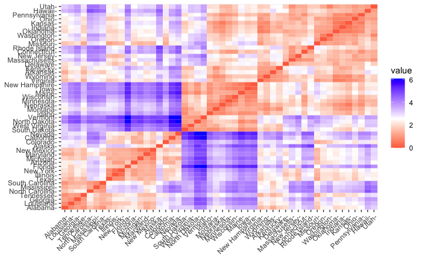

```r
fviz_dist(diss_matrix_all_crime)
```

```r
clusters_all_crime <- diss_matrix_all_crime %>%
  hclust(method = "complete")
```

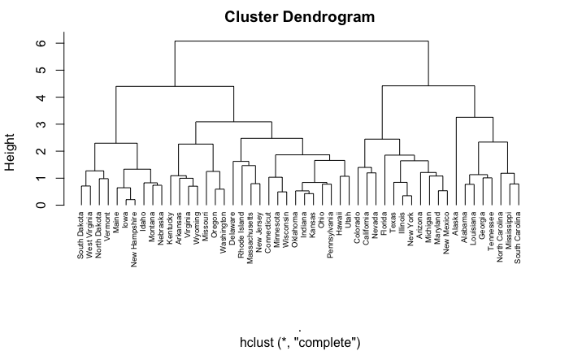

```r
clusters_all_crime %>%
plot(cex = 0.6, hang = -2)
```

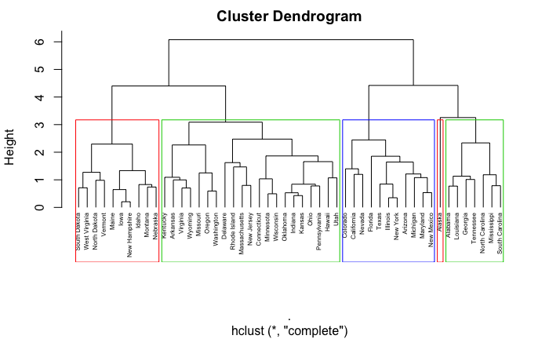

```r
plot(clusters_all_crime, cex = 0.5, hang = -5)
rect.hclust(clusters_all_crime, k = 5, border = 2:4)
```

```r
arrests_cluster_h4 <- arrests %>%
  mutate(clusters_all_crime = cutree(clusters_all_crime, 3))
head(arrests_cluster_h4)
```

|  | state | murder | assault | urban_pop | rape | clusters_all_crime |
| --- | --- | --- | --- | --- | --- | --- |
| 1 | Alabama | 1.24256408 | 0.7828393 | -0.5209066 | -0.003416473 | 1 |
| 2 | Alaska | 0.50786248 | 1.1068225 | -1.2117642 | 2.484202941 | 1 |
| 3 | Arizona | 0.07163341 | 1.4788032 | 0.9989801 | 1.042878388 | 2 |
| 4 | Arkansas | 0.23234938 | 0.2308680 | -1.0735927 | -0.184916602 | 3 |
| 5 | California | 0.27826823 | 1.2628144 | 1.7589234 | 2.067820292 | 2 |
| 6 | Colorado | 0.02571456 | 0.3988593 | 0.8608085 | 1.864967207 | 2 |

## K-means clustering with centroids.

```r
k_arrests <- USArrests %>%
  clean_names()%>%
  select(c(murder, assault))
head(k_arrests)
```

|  | murder | assault |
| --- | --- | --- |
| Alabama | 13.2 | 236 |
| Alaska | 10.0 | 263 |
| Arizona | 8.1 | 294 |
| Arkansas | 8.8 | 190 |
| California | 9.0 | 276 |
| Colorado | 7.9 | 204 |

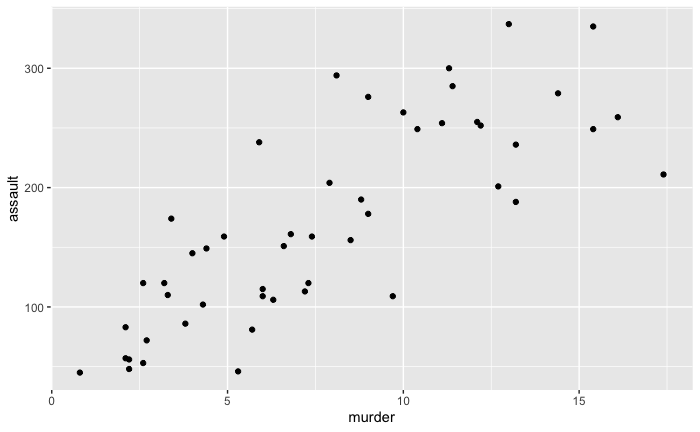

```r
ggplot(k_arrests, aes(murder, assault)) +
  geom_point()
```

scale the data, but not things like longitude/latitude.

```r
summary(k_arrests)
```

```
     murder          assault
 Min.   : 0.800   Min.   : 45.0
 1st Qu.: 4.075   1st Qu.:109.0
 Median : 7.250   Median :159.0
 Mean   : 7.788   Mean   :170.8
 3rd Qu.:11.250   3rd Qu.:249.0
 Max.   :17.400   Max.   :337.0
```

```r
k_arrests_scaled <- k_arrests %>%
  clean_names() %>%
  mutate_if(is.numeric, scale)

summary(k_arrests_scaled)
```

```
      murder.V1            assault.V1
 Min.   :-1.6044046   Min.   :-1.5090416
 1st Qu.:-0.8524835   1st Qu.:-0.7410815
 Median :-0.1235217   Median :-0.1411127
 Mean   : 0.0000000   Mean   : 0.0000000
 3rd Qu.: 0.7948553   3rd Qu.: 0.9388312
 Max.   : 2.2068599   Max.   : 1.9947764
```

```r
k_clustered_arrests <- kmeans(k_arrests_scaled, centers = 6, nstart = 25)
#nstart = 25 - defined number of iterations
k_clustered_arrests
```

```
K-means clustering with 6 clusters of sizes 10, 9, 7, 8, 8, 8

Cluster means:
       murder    assault
1  0.70531354  1.2688141
2 -1.18093078 -1.3210514
3 -0.20715961 -0.7582235
4 -0.92423166 -0.4305976
5  1.59269532  0.8878339
6 -0.04029379  0.1063745

Clustering vector:
 [1] 5 1 1 6 1 6 4 6 5 5 2 4 1 3 2 3 3 5 2 1 4 1 2 5 6 3 4 1 2 6 1 1 1 2 3 6 4 3 4 5 2 5 5 4 2 6
[47] 4 3 2 6

Within cluster sum of squares by cluster:
[1] 2.1018616 0.9594623 0.7436899 0.8700729 3.2796553 1.3691194
 (between_SS / total_SS =  90.5 %)

Available components:

[1] "cluster"      "centers"      "totss"        "withinss"     "tot.withinss" "betweenss"
[7] "size"         "iter"         "ifault"
```

```r
library(broom)
```

```r
tidy_k_clustered_arrests <- tidy(k_clustered_arrests)
tidy_k_clustered_arrests
```

| x1 | x2 | size | withinss | cluster |
| --- | --- | --- | --- | --- |
| 0.70531354 | 1.2688141 | 10 | 2.1018616 | 1 |
| -1.18093078 | -1.3210514 | 9 | 0.9594623 | 2 |
| -0.20715961 | -0.7582235 | 7 | 0.7436899 | 3 |
| -0.92423166 | -0.4305976 | 8 | 0.8700729 | 4 |
| 1.59269532 | 0.8878339 | 8 | 3.2796553 | 5 |
| -0.04029379 | 0.1063745 | 8 | 1.3691194 | 6 |

```r
glance(k_clustered_arrests)
```

| totss | tot.withinss | betweenss | iter |
| --- | --- | --- | --- |
| 98 | 9.323861 | 88.67614 | 3 |

```r
augment(k_clustered_arrests, arrests)
```

| state | murder | assault | urban_pop | rape | .cluster |
| --- | --- | --- | --- | --- | --- |
| Alabama | 1.24256408 | 0.78283935 | -0.52090661 | -0.003416473 | 5 |
| Alaska | 0.50786248 | 1.10682252 | -1.21176419 | 2.484202941 | 1 |
| Arizona | 0.07163341 | 1.47880321 | 0.99898006 | 1.042878388 | 1 |
| Arkansas | 0.23234938 | 0.23086801 | -1.07359268 | -0.184916602 | 6 |
| California | 0.27826823 | 1.26281442 | 1.75892340 | 2.067820292 | 1 |
| Colorado | 0.02571456 | 0.39885929 | 0.86080854 | 1.864967207 | 6 |
| Connecticut | -1.03041900 | -0.72908214 | 0.79172279 | -1.081740768 | 4 |
| Delaware | -0.43347395 | 0.80683810 | 0.44629400 | -0.579946294 | 6 |
| Florida | 1.74767144 | 1.97077766 | 0.99898006 | 1.138966691 | 5 |
| Georgia | 2.20685994 | 0.48285493 | -0.38273510 | 0.487701523 | 5 |

[output cut: 40 more lines]

```r
library(animation)
```

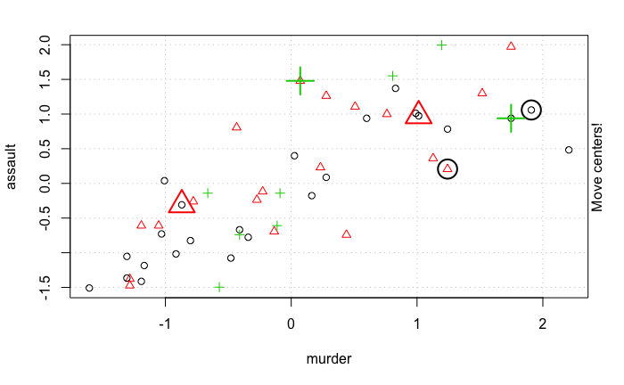

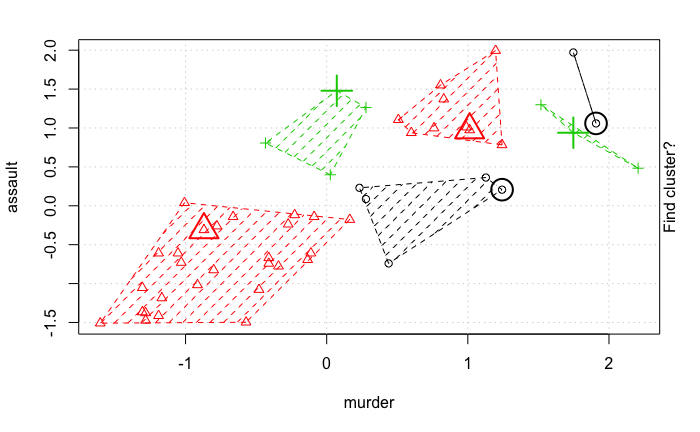

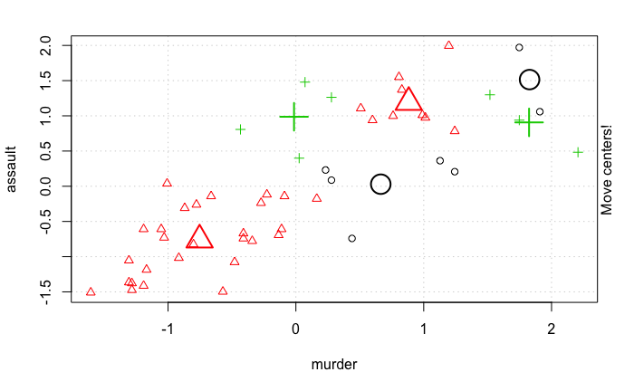

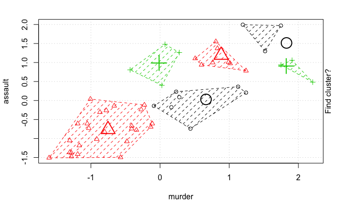

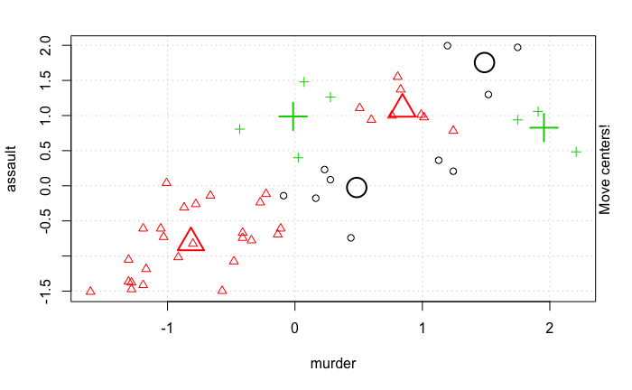

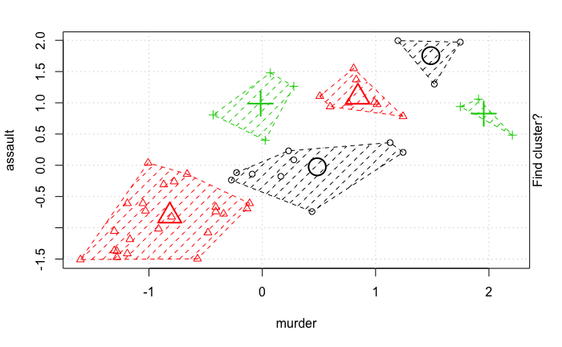

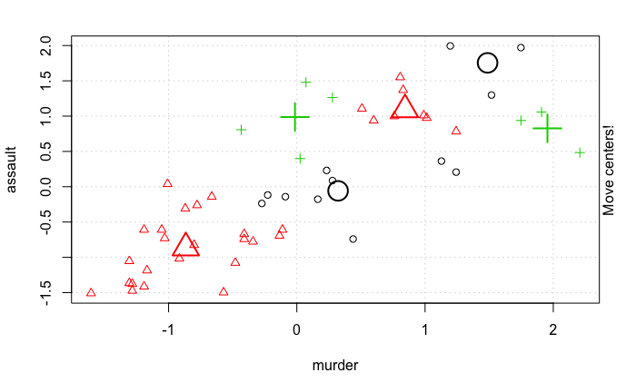

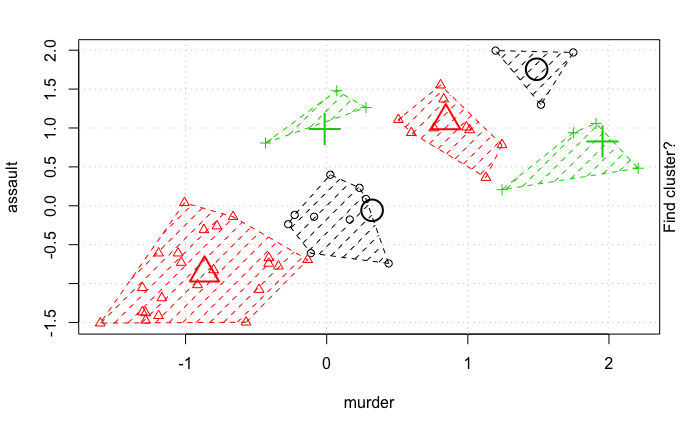

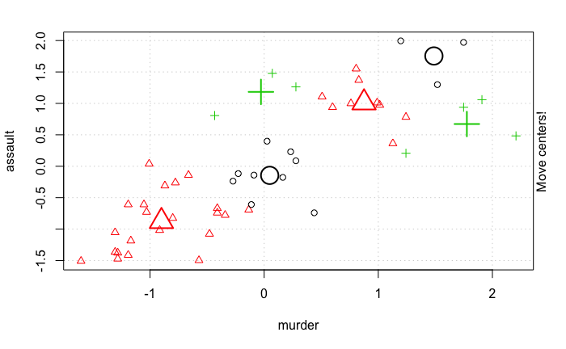

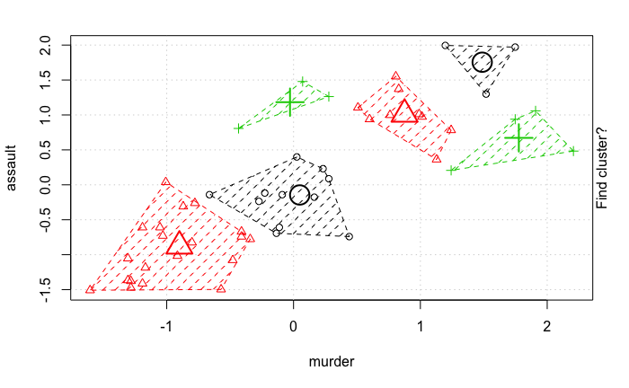

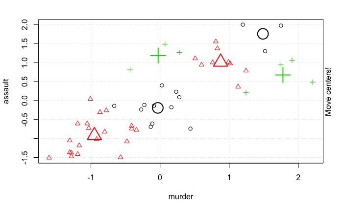

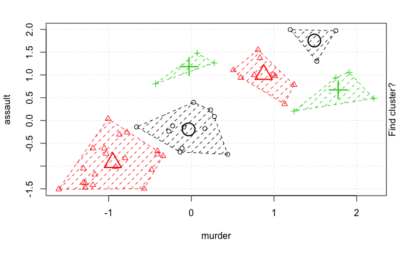

```r
k_arrests_scaled %>%
  kmeans.ani(centers = 6)
```

```r
glance(k_clustered_arrests)
```

| totss | tot.withinss | betweenss | iter |
| --- | --- | --- | --- |
| 98 | 9.323861 | 88.67614 | 3 |

withinss = within sum of squared

### How to pick number of K?

3 methods: could check all three and pick the most common K across three methods.

*elbow diagram* library(broom)

```r
max_k <- 20 #max K number

k_clusters <- tibble(k = 1:max_k) %>%
  mutate(
    kclust = map(k, ~kmeans(k_arrests_scaled, .x, nstart = 25)),
    tidied = map(kclust, tidy),
    glanced = map(kclust, glance),
    augmented = map(kclust, augment, arrests)
  )
k_clusters
```

| k | kclust | tidied | glanced | augmented |
| --- | --- | --- | --- | --- |
| 1 |  |  |  |  |
| 2 |  |  |  |  |
| 3 |  |  |  |  |
| 4 |  |  |  |  |
| 5 |  |  |  |  |
| 6 |  |  |  |  |
| 7 |  |  |  |  |
| 8 |  |  |  |  |
| 9 |  |  |  |  |
| 10 |  |  |  |  |

[output cut: 10 more lines]

```r
clusterings <- k_clusters %>%
  unnest(glanced)
clusterings
```

| k | kclust | tidied | totss | tot.withinss | betweenss | iter | augmented |
| --- | --- | --- | --- | --- | --- | --- | --- |
| 1 |  |  | 98 | 98.000000 | 1.421085e-14 | 1 |  |
| 2 |  |  | 98 | 28.989438 | 6.901056e+01 | 1 |  |
| 3 |  |  | 98 | 18.217665 | 7.978233e+01 | 2 |  |
| 4 |  |  | 98 | 14.072811 | 8.392719e+01 | 2 |  |
| 5 |  |  | 98 | 11.326651 | 8.667335e+01 | 3 |  |
| 6 |  |  | 98 | 9.193923 | 8.880608e+01 | 2 |  |
| 7 |  |  | 98 | 7.191133 | 9.080887e+01 | 3 |  |
| 8 |  |  | 98 | 6.244691 | 9.175531e+01 | 2 |  |
| 9 |  |  | 98 | 5.185396 | 9.281460e+01 | 4 |  |
| 10 |  |  | 98 | 4.470061 | 9.352994e+01 | 3 |  |

[output cut: 10 more lines]

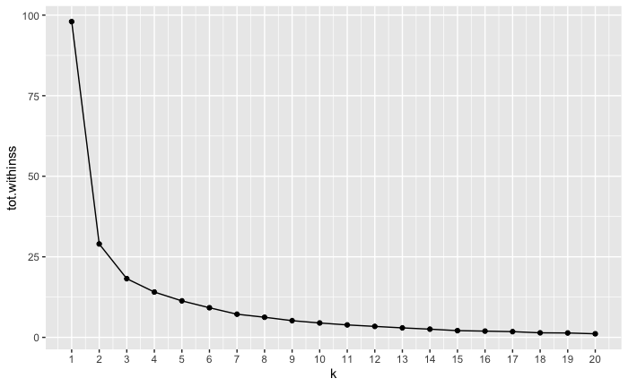

```r
ggplot(clusterings, aes(x =k, y = tot.withinss))+
  geom_point()+
  geom_line()+
  scale_x_continuous(breaks = seq(1,20, by = 1))
```

Could pick 2 or 3 clusters optimally.

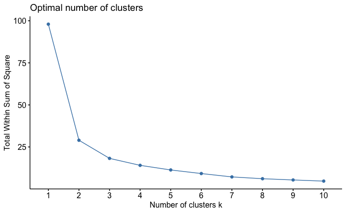

```r
fviz_nbclust(k_arrests_scaled, kmeans, method = "wss", nstart = 25)
```

*Silhouette coefficient*

S>0 - well clustered S=0 - close to boundary S>0 - not well clustered

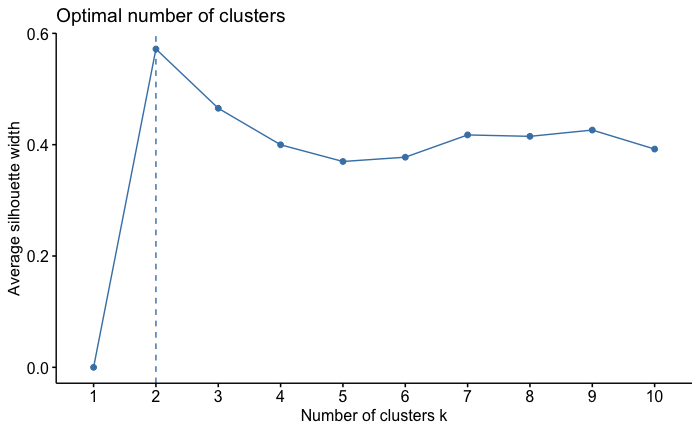

```r
fviz_nbclust(k_arrests_scaled, kmeans, method = "silhouette", nstart = 25)
```

k = 2 is the best, k = 3 not too far off

*gap statistic*

looking to maximise gap statistic, which number of K gives us max gap stat.

[output not shown]

[output not shown]

[output not shown]

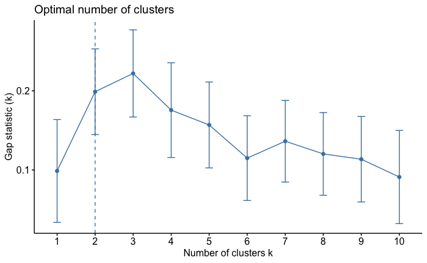

```r
fviz_nbclust(k_arrests_scaled, kmeans, method = "gap_stat", nstart = 25, k.max = 10)
```

#### Visualise with K=2

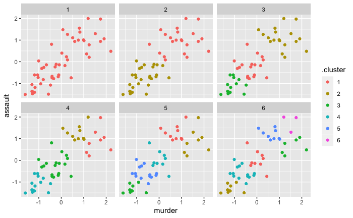

```r
clusterings %>%
  unnest(cols = c(augmented)) %>%
  filter(k <= 6) %>%
 ggplot(aes(x = murder, y = assault)) +
  geom_point(aes(color = .cluster)) +
  facet_wrap(~ k)
```

```r
library(tidyverse)
```

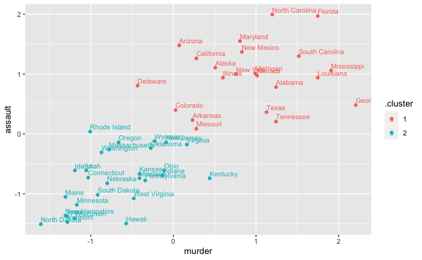

```r
clusterings %>%
  unnest(cols = c(augmented)) %>%
  filter(k == 2) %>%
 ggplot(aes(x = murder, y = assault, colour = .cluster, label = state)) +
  geom_point(aes(color = .cluster)) +
  geom_text(hjust = 0, vjust = - 0.5, size = 3)
```

```r
unnest(clusterings, cols = augmented)
```

| k | kclust | tidied | totss | tot.withinss | betweenss | iter | state | murder | assault | urban_pop | rape | .cluster |
| --- | --- | --- | --- | --- | --- | --- | --- | --- | --- | --- | --- | --- |
| 1 |  |  | 98 | 98.000000 | 1.421085e-14 | 1 | Alabama | 1.24256408 | 0.78283935 | -0.52090661 | -0.003416473 | 1 |
| 1 |  |  | 98 | 98.000000 | 1.421085e-14 | 1 | Alaska | 0.50786248 | 1.10682252 | -1.21176419 | 2.484202941 | 1 |
| 1 |  |  | 98 | 98.000000 | 1.421085e-14 | 1 | Arizona | 0.07163341 | 1.47880321 | 0.99898006 | 1.042878388 | 1 |
| 1 |  |  | 98 | 98.000000 | 1.421085e-14 | 1 | Arkansas | 0.23234938 | 0.23086801 | -1.07359268 | -0.184916602 | 1 |
| 1 |  |  | 98 | 98.000000 | 1.421085e-14 | 1 | California | 0.27826823 | 1.26281442 | 1.75892340 | 2.067820292 | 1 |
| 1 |  |  | 98 | 98.000000 | 1.421085e-14 | 1 | Colorado | 0.02571456 | 0.39885929 | 0.86080854 | 1.864967207 | 1 |
| 1 |  |  | 98 | 98.000000 | 1.421085e-14 | 1 | Connecticut | -1.03041900 | -0.72908214 | 0.79172279 | -1.081740768 | 1 |
| 1 |  |  | 98 | 98.000000 | 1.421085e-14 | 1 | Delaware | -0.43347395 | 0.80683810 | 0.44629400 | -0.579946294 | 1 |
| 1 |  |  | 98 | 98.000000 | 1.421085e-14 | 1 | Florida | 1.74767144 | 1.97077766 | 0.99898006 | 1.138966691 | 1 |
| 1 |  |  | 98 | 98.000000 | 1.421085e-14 | 1 | Georgia | 2.20685994 | 0.48285493 | -0.38273510 | 0.487701523 | 1 |

[output cut: 990 more lines]